# COMPSCIX 415.2 Homework 5/Midterm

# Data munging and wrangling

## Is this data “tidy”? If yes, leave it alone and go to the next problem. If no, make it tidy. Note: this data set is called table2 and is available in the tidyverse package. It should be ready for you to use after you’ve loaded the tidyverse package.

```r
table2
```

```
## # A tibble: 12 x 4
##    country      year type            count
##    <chr>       <int> <chr>           <int>
##  1 Afghanistan  1999 cases             745
##  2 Afghanistan  1999 population   19987071
##  3 Afghanistan  2000 cases            2666
##  4 Afghanistan  2000 population   20595360
##  5 Brazil       1999 cases           37737
##  6 Brazil       1999 population  172006362
##  7 Brazil       2000 cases           80488
##  8 Brazil       2000 population  174504898
##  9 China        1999 cases          212258
## 10 China        1999 population 1272915272
## 11 China        2000 cases          213766
## 12 China        2000 population 1280428583
```

```r
#No
```

```r
table2_tidy <- table2 %>%spread(key = type, value = count)
table2_tidy
```

```
## # A tibble: 6 x 4
##   country      year  cases population
##   <chr>       <int>  <int>      <int>
## 1 Afghanistan  1999    745   19987071
## 2 Afghanistan  2000   2666   20595360
## 3 Brazil       1999  37737  172006362
## 4 Brazil       2000  80488  174504898
## 5 China        1999 212258 1272915272
## 6 China        2000 213766 1280428583
```

## Create a new column in the diamonds data set called price_per_carat that shows the price of each diamond per carat (hint: divide). Only show me the code, not the output.

```r
diamonds <- mutate(diamonds,
                    price_per_carat=price/carat)
diamonds
```

```
## # A tibble: 53,940 x 11
##    carat cut       color clarity depth table price     x     y     z
##    <dbl> <ord>     <ord> <ord>   <dbl> <dbl> <int> <dbl> <dbl> <dbl>
##  1 0.23  Ideal     E     SI2      61.5    55   326  3.95  3.98  2.43
##  2 0.21  Premium   E     SI1      59.8    61   326  3.89  3.84  2.31
##  3 0.23  Good      E     VS1      56.9    65   327  4.05  4.07  2.31
##  4 0.290 Premium   I     VS2      62.4    58   334  4.2   4.23  2.63
##  5 0.31  Good      J     SI2      63.3    58   335  4.34  4.35  2.75
##  6 0.24  Very Good J     VVS2     62.8    57   336  3.94  3.96  2.48
##  7 0.24  Very Good I     VVS1     62.3    57   336  3.95  3.98  2.47
##  8 0.26  Very Good H     SI1      61.9    55   337  4.07  4.11  2.53
##  9 0.22  Fair      E     VS2      65.1    61   337  3.87  3.78  2.49
## 10 0.23  Very Good H     VS1      59.4    61   338  4     4.05  2.39
## # ... with 53,930 more rows, and 1 more variable: price_per_carat <dbl>
```

```r
analytic_questions <- diamonds %>%filter(price>1000 | carat<1.5) %>% select(carat, price, cut) %>%
    group_by(cut) %>%
    summarize(count=n()) %>%
    mutate( prop = count / sum(count))
analytic_questions
```

```
## # A tibble: 5 x 3
##   cut       count   prop
##   <ord>     <int>  <dbl>
## 1 Fair       1610 0.0298
## 2 Good       4906 0.0910
## 3 Very Good 12082 0.224
## 4 Premium   13791 0.256
## 5 Ideal     21551 0.400
```

# EDA

## During what time period is this data from?

```r
txhousing %>%distinct(year)
```

```
## # A tibble: 16 x 1
##     year
##    <int>
##  1  2000
##  2  2001
##  3  2002
##  4  2003
##  5  2004
##  6  2005
##  7  2006
##  8  2007
##  9  2008
## 10  2009
## 11  2010
## 12  2011
## 13  2012
## 14  2013
## 15  2014
## 16  2015
```

```r
#200-2015
```

## How many cities are represented?

```r
txhousing
```

```
## # A tibble: 8,602 x 9
##    city     year month sales   volume median listings inventory  date
##    <chr>   <int> <int> <dbl>    <dbl>  <dbl>    <dbl>     <dbl> <dbl>
##  1 Abilene  2000     1    72  5380000  71400      701       6.3 2000
##  2 Abilene  2000     2    98  6505000  58700      746       6.6 2000.
##  3 Abilene  2000     3   130  9285000  58100      784       6.8 2000.
##  4 Abilene  2000     4    98  9730000  68600      785       6.9 2000.
##  5 Abilene  2000     5   141 10590000  67300      794       6.8 2000.
##  6 Abilene  2000     6   156 13910000  66900      780       6.6 2000.
##  7 Abilene  2000     7   152 12635000  73500      742       6.2 2000.
##  8 Abilene  2000     8   131 10710000  75000      765       6.4 2001.
##  9 Abilene  2000     9   104  7615000  64500      771       6.5 2001.
## 10 Abilene  2000    10   101  7040000  59300      764       6.6 2001.
## # ... with 8,592 more rows
```

```r
txhousing %>% distinct(city)
```

```
## # A tibble: 46 x 1
##    city
##    <chr>
##  1 Abilene
##  2 Amarillo
##  3 Arlington
##  4 Austin
##  5 Bay Area
##  6 Beaumont
##  7 Brazoria County
##  8 Brownsville
##  9 Bryan-College Station
## 10 Collin County
## # ... with 36 more rows
```

```r
#46
```

## Which city, month and year had the highest number of sales?

```r
txhousing
```

```
## # A tibble: 8,602 x 9
##    city     year month sales   volume median listings inventory  date
##    <chr>   <int> <int> <dbl>    <dbl>  <dbl>    <dbl>     <dbl> <dbl>
##  1 Abilene  2000     1    72  5380000  71400      701       6.3 2000
##  2 Abilene  2000     2    98  6505000  58700      746       6.6 2000.
##  3 Abilene  2000     3   130  9285000  58100      784       6.8 2000.
##  4 Abilene  2000     4    98  9730000  68600      785       6.9 2000.
##  5 Abilene  2000     5   141 10590000  67300      794       6.8 2000.
##  6 Abilene  2000     6   156 13910000  66900      780       6.6 2000.
##  7 Abilene  2000     7   152 12635000  73500      742       6.2 2000.
##  8 Abilene  2000     8   131 10710000  75000      765       6.4 2001.
##  9 Abilene  2000     9   104  7615000  64500      771       6.5 2001.
## 10 Abilene  2000    10   101  7040000  59300      764       6.6 2001.
## # ... with 8,592 more rows
```

```r
txhousing_analytic_questions <- txhousing %>% select(city, month, year, sales) %>%
    group_by(city, year, month) %>%
    summarize(sumBySales=sum(sales)) %>%
    arrange(desc(sumBySales))
txhousing_analytic_questions
```

```
## # A tibble: 8,602 x 4
## # Groups:   city, year [736]
##    city     year month sumBySales
##    <chr>   <int> <int>      <dbl>
##  1 Houston  2015     7       8945
##  2 Houston  2006     6       8628
##  3 Houston  2013     7       8468
##  4 Houston  2015     6       8449
##  5 Houston  2013     5       8439
##  6 Houston  2014     6       8391
##  7 Houston  2014     7       8391
##  8 Houston  2014     8       8167
##  9 Houston  2013     8       8155
## 10 Houston  2006     5       8040
## # ... with 8,592 more rows
```

```r
#Houston, 2015, 7
```

## What kind of relationship do you think exists between the number of listings and the number of sales? Check your assumption and show your work.

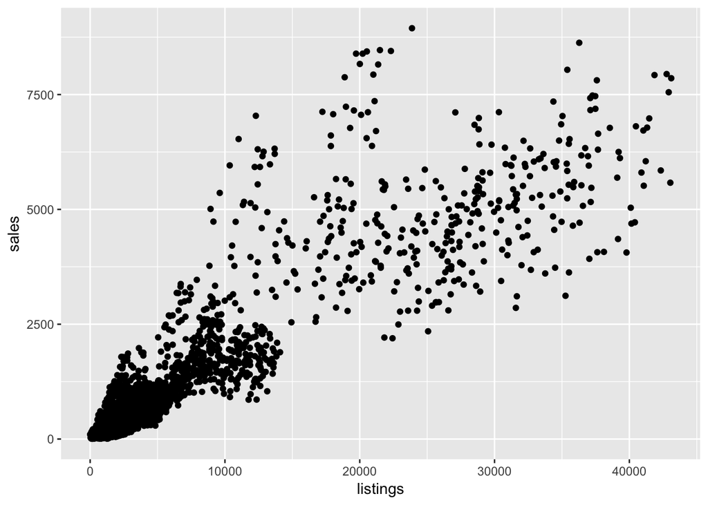

```r
ggplot(data = txhousing) +
  geom_point(mapping = aes(x = listings, y = sales))
```

```r
#looks like a positive relationship
```